# Tarea 5: 26/02/2018

*175904 - Jorge III Altamirano Astorga*

### Pregunta 1

- En la sección 5.6.1, mejora la función *ejemplo* para que en lugar del número de evaluaciones de las películas de el número de pares de evaluaciones que se usaron para calcular la similitud coseno (nota que el *left_join* tiene varias calificaciones vacías (NA)). Esta es la cantidad más relevante para filtrar después. En los ejercicios siguientes, filtra usando este número de pares en lugar de número de evaluaciones:

```r
muestra_nf <- readRDS('../../../datos/netflix/dat_muestra_nflix.rds')
pelis_nombres <- read_csv('../../../datos/flujos/movies_title_fix.csv',
                          col_names = FALSE, na = c("", "NA", "NULL"))
names(pelis_nombres) <- c('peli_id','año','nombre')
```

```r
# set.seed(175904)
set.seed(28882)
valida_pelis <- sample(unique(muestra_nf$peli_id), 2000)
valida_usuarios <- sample(unique(muestra_nf$usuario_id), 20000)
dat_2 <- muestra_nf %>%
  mutate(valida_usu = usuario_id %in% valida_usuarios) %>%
  mutate(valida_peli = peli_id %in% valida_pelis)
dat_valida <- filter(dat_2, valida_usu & valida_peli)
dat_entrena <- filter(dat_2, !valida_usu | !valida_peli)
medias_pred <- dat_entrena %>% #na.omit %>%
  group_by(peli_id) %>%
  summarise(media_pred = mean(calif), num_pred = length(calif))
dat_valida_pred <- left_join(dat_valida, medias_pred)
nrow(medias_pred)
```

```
## [1] 17770
```

Cuando filtramos con más de 1000 calificadores…

```r
medias_pred2 <- medias_pred %>%
  filter(num_pred > 1000) %>%
  arrange(desc(num_pred)) %>%
  left_join(pelis_nombres, c("peli_id", "peli_id")) %>%
  select(año, nombre, media_pred, num_pred)
medias_pred2
```

| año | nombre | media_pred | num_pred |
| --- | --- | --- | --- |
| 2000 | Miss Congeniality | 3.369584 | 48633 |
| 1996 | Independence Day | 3.724490 | 45051 |
| 2004 | The Day After Tomorrow | 3.442028 | 40787 |
| 2003 | Pirates of the Caribbean: The Curse of the Black Pearl | 4.147660 | 40627 |
| 1990 | Pretty Woman | 3.912176 | 40217 |
| 1994 | Forrest Gump | 4.300150 | 38071 |
| 1999 | The Green Mile | 4.305159 | 37800 |
| 1997 | Con Air | 3.454777 | 36928 |
| 2002 | Sweet Home Alabama | 3.538098 | 36787 |
| 2001 | Pearl Harbor | 3.393329 | 36214 |

[output cut: 3164 more lines]

Graficándolo, así se ve…

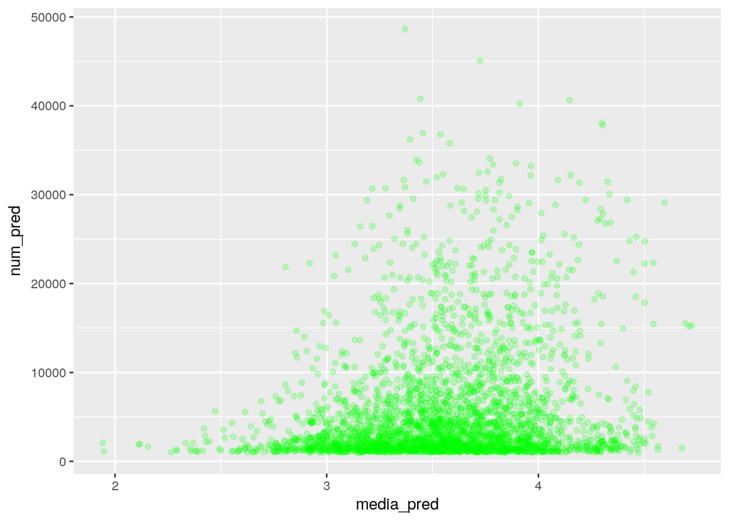

```r
ggplot(medias_pred2, aes(media_pred, num_pred)) +
  geom_point(alpha=0.2, colour = "green")
```

### Pregunta 2

- En la parte de filtrado colaborativo usando vecinos cercanos, encuentra dos películas que tengan similitud coseno negativa relativamente grande, y dos películas que tengan similitud coseno positivo relativamente grande.

```r
sim_cos <- function(x,y){
  sum(x*y, na.rm = T)/(sqrt(sum(x^2, na.rm = T))*sqrt(sum(y^2, na.rm = T)))
}
```

```r
dat_entrena_c <- dat_entrena %>%
  group_by(usuario_id) %>%
  mutate(calif_c = calif - mean(calif))
## calculamos un id secuencial.
dat_entrena_c$id_seq <- as.numeric(factor(dat_entrena_c$usuario_id))
filter(pelis_nombres, str_detect(nombre,'Miss Congeniality'))
```

| peli_id | año | nombre |
| --- | --- | --- |
| 5317 | 2000 | Miss Congeniality |
| 16113 | 2005 | Miss Congeniality 2: Armed and Fabulous |

```r
dat_1 <- filter(dat_entrena_c, peli_id==5317)
filter(pelis_nombres, str_detect(nombre,'Clockwork Orange'))
```

| peli_id | año | nombre |
| --- | --- | --- |
| 10451 | 1971 | A Clockwork Orange |

```r
dat_2 <- filter(dat_entrena_c, peli_id==10451)
filter(pelis_nombres, str_detect(nombre,'Pulp Fiction'))
```

| peli_id | año | nombre |
| --- | --- | --- |
| 3524 | 1994 | Pulp Fiction: Bonus Material |
| 11064 | 1994 | Pulp Fiction |

```r
dat_3 <- filter(dat_entrena_c, peli_id==11064)
comunes <- inner_join(
  dat_1[, c('usuario_id','calif_c')],
  dat_2[, c('usuario_id','calif_c')] %>%
    rename(calif_c_2=calif_c),
  by = c("usuario_id", "usuario_id"))
comunes <- inner_join(
  comunes,
  dat_3[, c('usuario_id','calif_c')] %>%
                        rename(calif_c_3=calif_c),
  by = c("usuario_id", "usuario_id"))
comunes
```

| usuario_id | calif_c | calif_c_2 | calif_c_3 |
| --- | --- | --- | --- |
| 29278 | -0.2166666667 | -0.2166666667 | -0.216666667 |
| 341797 | -1.4465408805 | 0.5534591195 | 0.553459119 |
| 4973 | 0.0809047412 | 1.0809047412 | 2.080904741 |
| 685 | -1.6487854251 | -2.6487854251 | 1.351214575 |
| 20539 | -1.2849702381 | 0.7150297619 | 0.715029762 |
| 158479 | 0.2721641502 | -0.7278358498 | 0.272164150 |
| 4922 | -1.1951530612 | 0.8048469388 | 1.804846939 |
| 40527 | -0.5046132009 | -2.5046132009 | -1.504613201 |
| 4931 | -0.8407407407 | 1.1592592593 | 0.159259259 |
| 224278 | -1.3800000000 | 0.6200000000 | 0.620000000 |

[output cut: 7546 more lines]

Las 3 películas tienen muchas calificaciones, de acuerdo al punto anterior:

```r
filter(medias_pred,
       peli_id==5317 |
         peli_id==10451 |
         peli_id==11064) %>%
  left_join(pelis_nombres, c("peli_id", "peli_id"))
```

| peli_id | media_pred | num_pred | año | nombre |
| --- | --- | --- | --- | --- |
| 5317 | 3.369584 | 48633 | 2000 | Miss Congeniality |
| 10451 | 3.720082 | 15551 | 1971 | A Clockwork Orange |
| 11064 | 4.092459 | 31668 | 1994 | Pulp Fiction |

Comparando *Miss Congeniality* con *Clockwork Orange*: no son *nada* similares

```r
sim_cos(comunes$calif_c, comunes$calif_c_2)
```

```
## [1] -0.2299315
```

```r
sim_cos(comunes$calif_c, comunes$calif_c_3)
```

```
## [1] -0.4178888
```

En cambio *Clockwork Orange* y *Pulp Fiction* son mucho más *afines*

```r
sim_cos(comunes$calif_c_2, comunes$calif_c_3)
```

```
## [1] 0.2970552
```

```r
library(textreuse)
```

```r
options("mc.cores" = 14L)
minhash <- minhash_generator(50)
shingle_chars <- function(string, lowercase = FALSE, k = 4){
    # produce shingles (con repeticiones)
    if(lowercase) {
      string <- str_to_lower(string)
    }
    shingles <- seq(1, nchar(string) - k + 1) %>%
        map_chr(function(x) substr(string, x, x + k - 1))
    shingles
  }
sim_cos2 <- function(x,y){
  x = x %>% unlist %>% as.double
  y = y %>% unlist %>% as.double
  sum(x*y, na.rm = T)/(sqrt(sum(x^2, na.rm = T))*sqrt(sum(y^2, na.rm = T)))
}
corpus_tweets <- TextReuseCorpus(
  text = comunes %>% select(-usuario_id) %>% as.character ,
  tokenizer = shingle_chars,
  k = 5,
  lowercase = TRUE,
  hash_func = minhash,
  keep_tokens = TRUE,
  keep_text = TRUE,
  skip_short = FALSE)
pares <- pairwise_compare(corpus_tweets[1:100], sim_cos2, progress = F)
```

[output not shown]

[output cut: 712 more lines]

[output not shown]

```r
pares
```

[output not shown]

[output cut: 854 more lines]

[output not shown]

### Pregunta 3

- Escoge una película que te interese y muestra los 10 vecinos más cercanos en términos de similitud coseno (filtra películas usando número de pares que se usaron para calcular la similitud).

Sacando las pelis con más de 30,000 reviews:

```r
top_30 <- medias_pred %>%
  filter(num_pred > 30000)
top_30 %>% left_join(pelis_nombres) %>% arrange(desc(num_pred))
```

| peli_id | media_pred | num_pred | año | nombre |
| --- | --- | --- | --- | --- |
| 5317 | 3.369584 | 48633 | 2000 | Miss Congeniality |
| 15124 | 3.724490 | 45051 | 1996 | Independence Day |
| 15205 | 3.442028 | 40787 | 2004 | The Day After Tomorrow |
| 1905 | 4.147660 | 40627 | 2003 | Pirates of the Caribbean: The Curse of the Black Pearl |
| 6287 | 3.912176 | 40217 | 1990 | Pretty Woman |
| 11283 | 4.300150 | 38071 | 1994 | Forrest Gump |
| 16377 | 4.305159 | 37800 | 1999 | The Green Mile |
| 16242 | 3.454777 | 36928 | 1997 | Con Air |
| 15582 | 3.538098 | 36787 | 2002 | Sweet Home Alabama |
| 9340 | 3.393329 | 36214 | 2001 | Pearl Harbor |

[output cut: 29 more lines]

```r
filter(dat_entrena_c[, c(1, 5,8)], peli_id==10451)
```

| peli_id | usuario_id | calif_c |
| --- | --- | --- |
| 10451 | 171646 | -0.2024793388 |
| 10451 | 388258 | 0.4333333333 |
| 10451 | 548 | 0.2961956522 |
| 10451 | 29277 | 1.3600000000 |
| 10451 | 29278 | -0.2166666667 |
| 10451 | 341797 | 0.5534591195 |
| 10451 | 4973 | 1.0809047412 |
| 10451 | 76885 | -1.5498281787 |
| 10451 | 181370 | 1.5244618395 |
| 10451 | 685 | -2.6487854251 |

[output cut: 9990 more lines]

```r
lapply(top_30$peli_id, function(x){
  print(x)
}) %>% invisible
```

```
## [1] 571
## [1] 1905
## [1] 1962
## [1] 2152
## [1] 3860
## [1] 3938
## [1] 4306
## [1] 4432
## [1] 4996
## [1] 5317
## [1] 5496
## [1] 6037
## [1] 6287
## [1] 6386
## [1] 6972
```

[output cut: 24 more lines]

```r
comunes2 <- inner_join(
  filter(dat_entrena_c, peli_id==10451),
  filter(dat_entrena_c, peli_id==10452) %>%
    rename(calif_c_2=calif_c),
  by = c("usuario_id", "usuario_id"))
sim_cos(comunes2$calif_c, comunes2$calif_c_2)
```

```
## [1] 0.006119154
```